# **ssvTracks**

Joseph R Boyd

2022-07-15

## 0.1 Overview

**ssvTracks** is a specialization of **seqsetvis** for “track” style visualization of individual genomic regions.

All output plot are ggplots and therefore easily customized. **ssvTracks** also provides functions for aligning axes of multiple plots vertically for the assembly of multi-part tracks.

Track types supported:

1. track_chip: ChIP-seq style tracks, pileups from bams or signal from bigWigs. Also appropriate for ATAC-seq and Cut&Run.
2. track_rna: RNA-seq style tracks, pileups from single-end (SE) and paired-end (PE) bam files. Includes spliced read visualization.
3. track_features: similar to how UCSC visualizes bed files. Any interval stored in a GRanges object can be visualized.
4. track_gene_reference: visualize genes and their promoters in the query region.
5. track_gene_transcripts: visualize all transcripts for a single gene.

## 0.2 Setup

```r
suppressPackageStartupMessages({
  library(ssvTracks)
  library(magrittr)
  library(GenomicRanges)
})
```

```r
gff_gr = rtracklayer::import.gff("~/indexes/HG38canon/GTF/gencode.v36.annotation.gtf")
ref_gr = split(gff_gr, gff_gr$type)

ex_gr = subset(ref_gr$exon, gene_name == "ESR1")
tx_gr = subset(ref_gr$transcript, gene_name == "ESR1")
query_gr.l = reduce(promoters(tx_gr, 2e4, 2e4))

query_gr = query_gr.l[2]
```

## 0.3 track_chip

```r
chip_files = "/slipstream/galaxy/uploads/working/qc_framework/output/" %>%
  dir(., pattern = "pooled", full.names = TRUE) %>%
  dir(pattern = ".bam$", full.names = TRUE)
basename(chip_files)
```

```
## [1] "MCF10A_H3K4ME3_pooled.bam" "MCF10A_input_pooled.bam"   "MCF7_H3K4ME3_pooled.bam"   "MCF7_input_pooled.bam"     "MDA231_H3K4ME3_pooled.bam" "MDA231_input_pooled.bam"
```

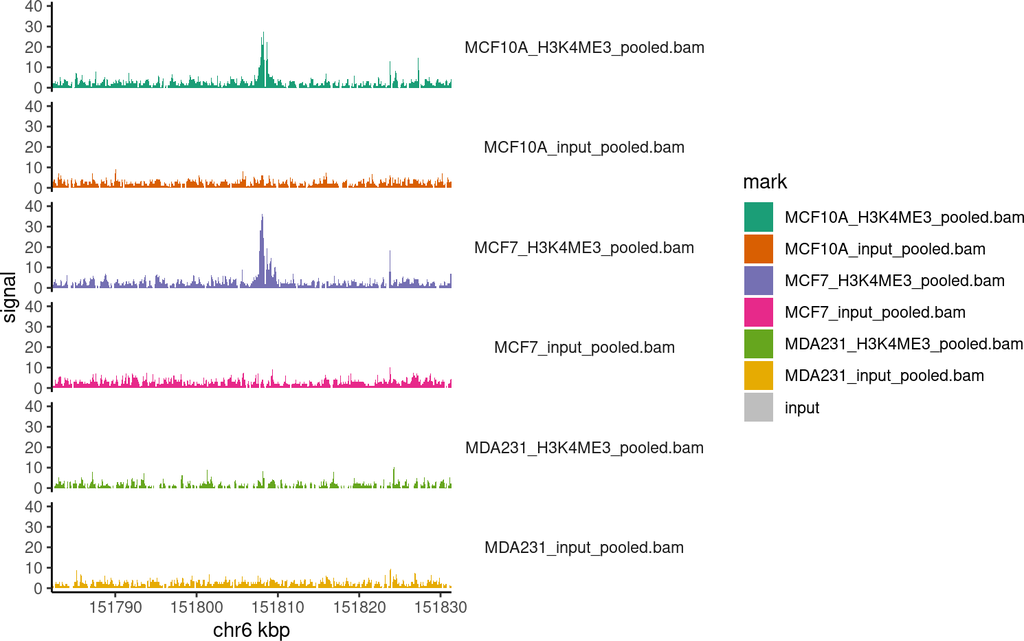

```r
track_chip(signal_files = chip_files,
           query_gr = query_gr)
```

```r
chip_cfg = data.frame(file = chip_files)
chip_cfg$sample = chip_cfg$file %>%
  basename %>%
  sub("_pooled.bam", "", x = .)

# library(tidyverse)
chip_cfg = tidyr::separate(chip_cfg,
                           sample,
                           into = c("cell", "mark"),
                           sep = "_",
                           remove = FALSE)
```

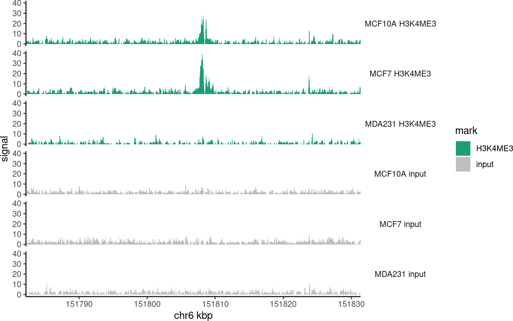

```r
chip_cfg$sample = factor(chip_cfg$sample)
track_chip(signal_files = chip_cfg,
           query_gr = query_gr)
```

[figure not shown]

```r
#factor levels for sample should control order
chip_cfg$sample = factor(chip_cfg$sample, levels = levels(chip_cfg$sample)[c(2, 3, 1, 5, 6, 4)])
track_chip(signal_files = chip_cfg,
           query_gr = query_gr)
```

## 0.4 track_gene_reference

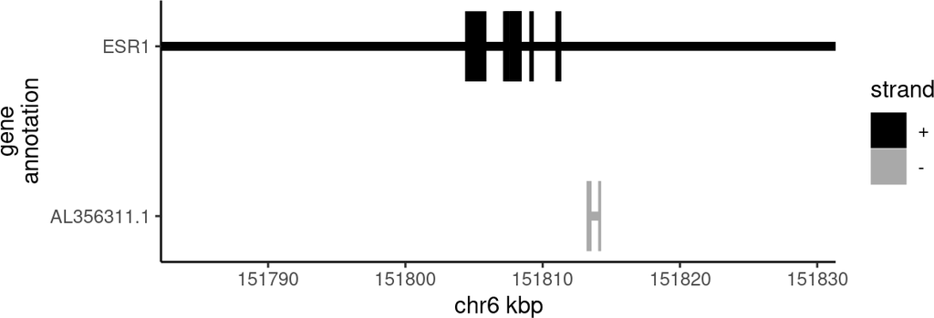

```r
track_gene_reference(gff_gr,
                     query_gr = query_gr)
```

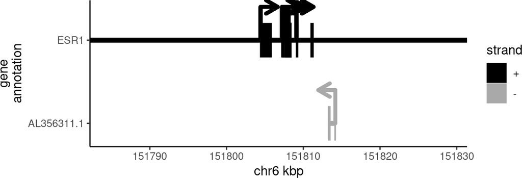

```r
track_gene_reference(gff_gr,
                     query_gr = query_gr,
                     show_tss = TRUE)
```

One of the more effective and simplest ways to clean GENCODE genes up is by selecting for only transcripts with the “basic” tag.

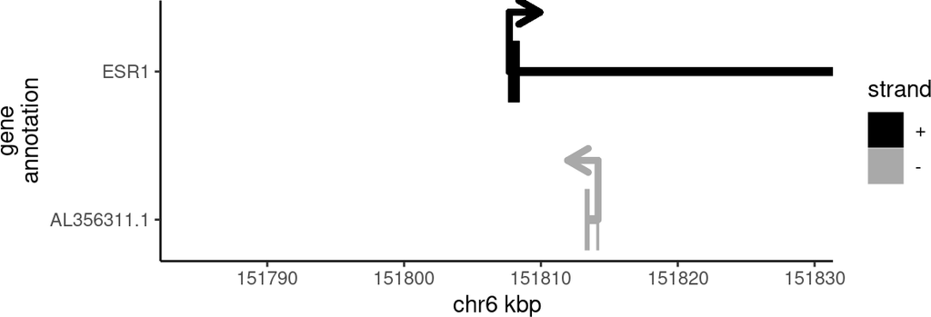

```r
track_gene_reference(subset(gff_gr, tag == "basic"),
                     query_gr = query_gr,
                     show_tss = TRUE)
```

## 0.5 track_gene_transcripts

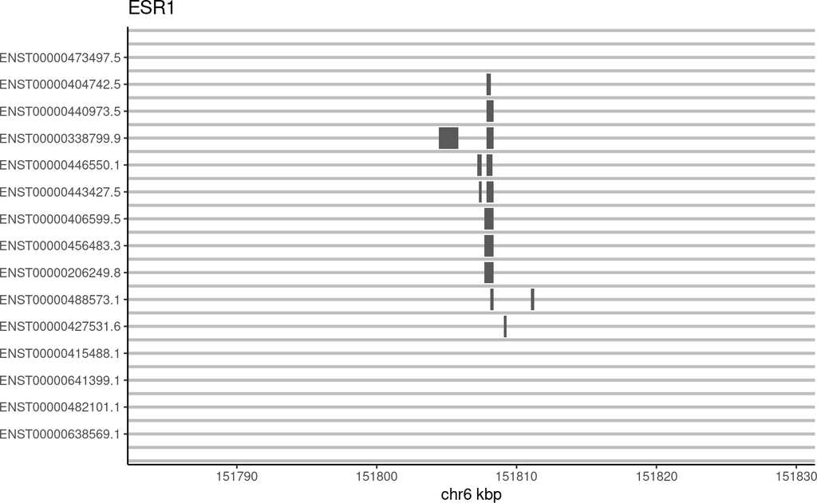

```r
track_gene_transcripts(gff_gr, query_gr = query_gr, sel_gene_name = "ESR1")
```

## 0.6 track_rna.SE

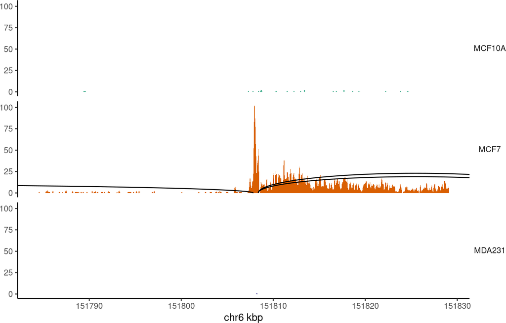

```r
rna_files.all = dir("~/../joeboyd/R_workspace.t630/RNAseq_BRCA/alignment/", pattern = "M.+bam$", full.names = TRUE)
rna_files = c(
  MCF10A = rna_files.all[grepl("MCF10A_RNA-Seq_R5", rna_files.all)],
  MCF7 = rna_files.all[grepl("MCF7_RNA-Seq_R1_GSM1944518", rna_files.all)],
  MDA231 = rna_files.all[grepl("DA-MB-231_RNA-Seq_R1_GSM1944521", rna_files.all)]
)


track_rna.SE(rna_files, query_gr = query_gr) +
  guides(color = "none", fill = "none")
```

```r
rna_cfg = data.frame(file = rna_files)
rna_cfg$sample = basename(rna_cfg$file)
rna_cfg = rna_cfg %>%
  tidyr::separate(.,
                  col = "sample",
                  sep = "_",
                  into = c("cell"),
                  remove = FALSE,
                  extra = "drop")
rna_cfg$cell = rna_cfg$cell %>%
  sub("MDA-MB-231", "MDA231", .)
```

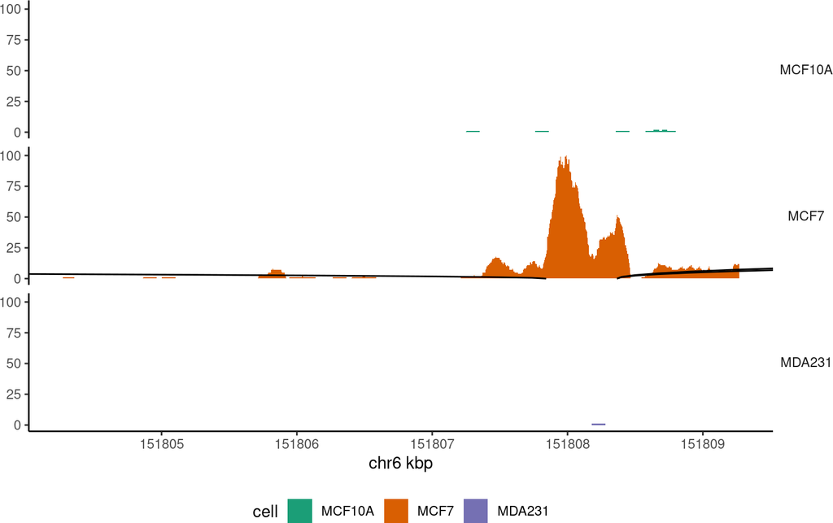

```r
track_rna.SE(rna_cfg,
             query_gr = resize(query_gr, 5e3, fix = "center"),
             fill_VAR = "cell",
             facet_VAR = "cell",
             nwin = Inf,
             legend.position = "bottom")
```

## 0.7 track_features

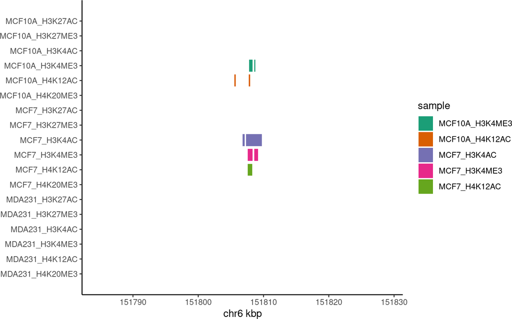

```r
np_files = "/slipstream/galaxy/uploads/working/qc_framework/output/" %>%
  dir(., pattern = "pooled", full.names = TRUE) %>%
  dir(pattern = "35000.narrowPeak$", full.names = TRUE)
names(np_files) = np_files %>%
  basename %>%
  sub("_pooled.+", "", .)
np_grs = seqsetvis::easyLoad_narrowPeak(np_files)
track_features(np_grs, query_gr = query_gr)
```

It is a bit different to bring meta data into track_features(). We need to supply a separate data.frame as sample_info_df. It is critical that the values of sample_info_df.name_VAR (default “sample”) match the names of the GRanges list iin feature_grs.

```r
np_cfg = data.frame(file = np_files)
np_cfg$sample = np_cfg$file %>%
  basename %>%
  sub("_pooled.+", "", .)
np_cfg = np_cfg %>%
  tidyr::separate(., "sample", sep = "_", into = c("cell", "mark"), remove = FALSE)
```

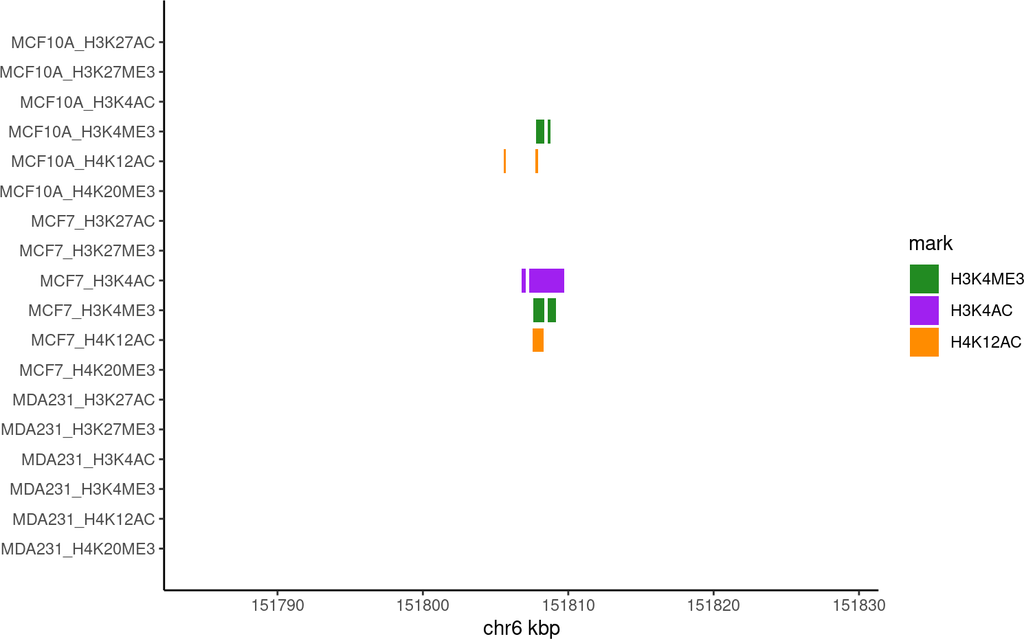

```r
track_features(
  feature_grs = np_grs,
  query_gr = query_gr,
  sample_info_df = np_cfg,
  sample_info_df.fill_VAR = "mark",
  fill_mapping = c("H3K4ME3" = "forestgreen",
                   "H3K4AC" = "purple",
                   "H4K12AC" = "darkorange"))
```

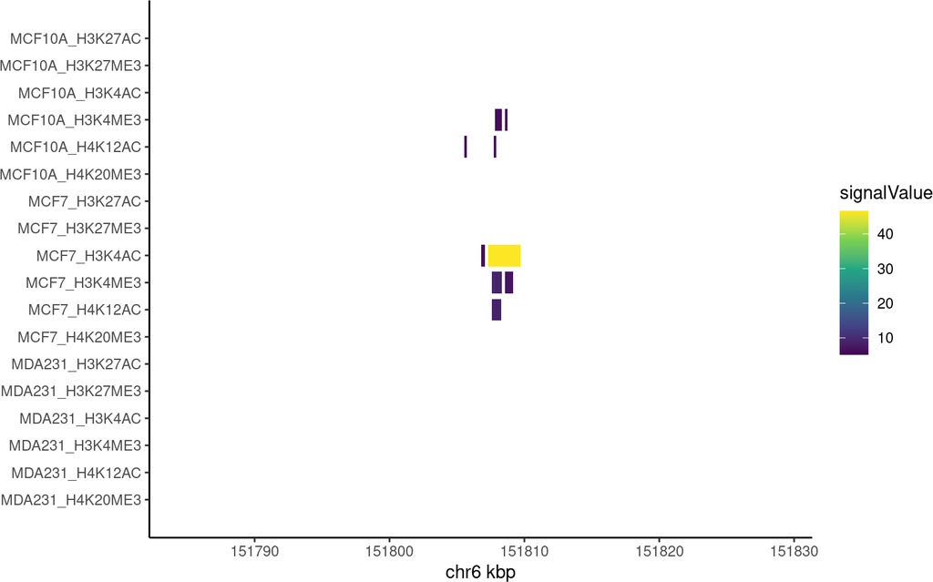

```r
track_features.numeric(
  np_grs,
  query_gr = query_gr,
  fill_VAR = "signalValue"
) +
  scale_fill_viridis_c()
```

## 0.8 assemble_tracks

If we create a list of *ssvTrack* generated plots (or any or other ggplot that makes sense to include; genomic position on x-axis) we can then assemble them into a single consistent figure.

```r
plots1 = list(
  track_chip(
    chip_cfg,
    query_gr = query_gr
  ),
  track_rna.SE(
    rna_cfg,
    query_gr = query_gr,
    fill_VAR = "cell",
    facet_VAR = "cell"
  ),
  track_features(
    np_grs[grepl("K4ME3", names(np_grs))],
    query_gr = query_gr,
    sample_info_df = np_cfg,
    sample_info_df.fill_VAR = "cell"
  ),
  track_gene_reference(
    subset(gff_gr, tag == "basic"),
    query_gr = query_gr,
    show_tss = TRUE
  ),
  track_gene_transcripts(
    gff_gr,
    query_gr = query_gr,
    sel_gene_name = "ESR1"
  )
)
```

**assemble_tracks** aligns all plots in a single column. This ensures a consistent x-axis and margin size. Because of the method used to align margins, all margins will be widened to the maximum margin present. Therefore if a single plot has a particularly wide legend element it can cause all plots to become squished. You may wish to disable or modify legends or similar elements to avoid this behavior.

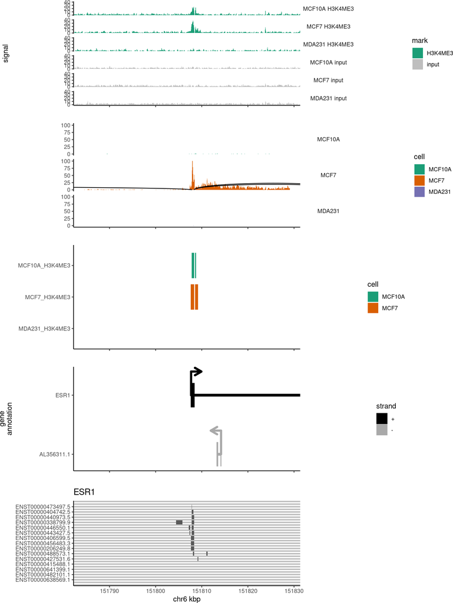

```r
assemble_tracks(
  plots1,
  query_gr = query_gr
)
```

The **rel_heights** parameter allows control of each track plot’s relative size. By default all plots will be given the same space, which is often inappropriate.

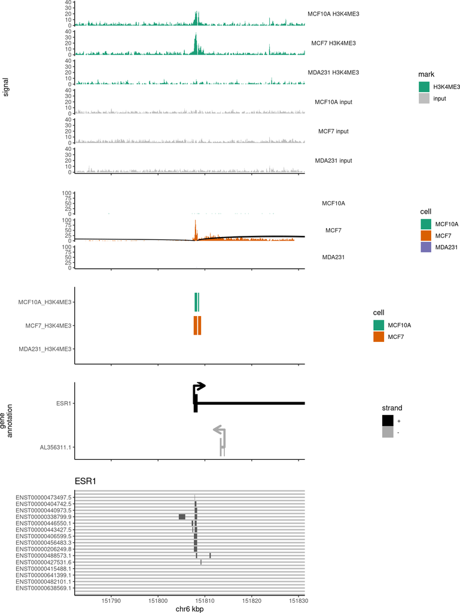

```r
assemble_tracks(
  plots1,
  query_gr = query_gr,
  rel_heights = c(2, 1, 1, 1, 1.5)
)
```